# Determinants of Life Satisfaction in Early Adulthood: Health, Employment, Education, and Parental Involvement

Liqi Liang

2024

## Overview

This analysis examines factors associated with life satisfaction among young adults at age 22, using data from the ICPSR Transition to Adulthood Supplement (TAS), Waves 1–5, 2005–2011 (ICPSR 31622). The central question is whether employment status moderates the relationship between health and life satisfaction, while also accounting for education, parental involvement, gender, and race.

The analysis proceeds in three stages: a baseline OLS model, a corrected model with outlier removal and variable transformations, and an interaction model testing whether the effect of health on life satisfaction differs by employment status.

```r
rm(list = ls(all.names = TRUE))
library(knitr)
library(stargazer)
library(ggplot2)
```

## Data Preparation

### Load and Subset

```r
load("df.rda")
df <- da31622.0012

subdata <- df[, c(
  "K7I1",   # Life satisfaction
  "K7G1",   # CPS involvement
  "K7H1_1", # Race: White
  "K7H1_2", # Race: Black or African American
  "K7H1_3", # Race: Asian or Pacific Islander
  "K7H1_4", # Race: Native American or Alaskan Native
  "K7H1_5", # Race: Other
  "K7H5",   # Gender
  "K7C1",   # Work last week
  "K7E1",   # Involvement of biological mother
  "K7E7",   # Involvement of biological father
  "K7I2",   # Health
  "K7B1"    # Education
)]

colnames(subdata) <- c(
  "life_satisfaction", "cps_involvement",
  "race_white", "race_black", "race_asian", "race_native", "race_other",
  "gender", "work_last_week",
  "mother_involvement", "father_involvement",
  "health", "education"
)
```

### Recode Variables

Survey responses are stored as labeled strings; the following recodes them to numeric values. Life satisfaction is reverse-coded so that higher values indicate greater satisfaction. Health is reverse-coded so that higher values indicate better health.

```r
# Remove "not in wave" observations
subdata <- subdata[!apply(subdata, 1, function(row) any(grepl("\\(-9\\) -9 Not in wave", row))), ]

subdata$life_satisfaction <- sapply(subdata$life_satisfaction, function(v) {
  if (grepl("\\(1\\)", v)) 4 else if (grepl("\\(2\\)", v)) 3 else if (grepl("\\(3\\)", v)) 2 else if (grepl("\\(4\\)", v)) 1 else NA
})

subdata$cps_involvement <- sapply(subdata$cps_involvement, function(v) {
  if (grepl("\\(1\\)", v)) 1 else if (grepl("\\(2\\)", v)) 0 else NA
})

for (race_var in c("race_white", "race_black", "race_asian", "race_native", "race_other")) {
  subdata[[race_var]] <- sapply(subdata[[race_var]], function(v) {
    if (grepl("\\(1\\)", v)) 1 else if (grepl("\\(0\\)", v)) 0 else NA
  })
}

subdata$gender <- sapply(subdata$gender, function(v) {
  if (grepl("\\(001\\)", v)) 1 else if (grepl("\\(002\\)", v)) 2 else NA
})

subdata$work_last_week <- sapply(subdata$work_last_week, function(v) {
  if (grepl("\\(1\\)", v)) 1 else if (grepl("\\(2\\)", v)) 0 else NA
})

for (par_var in c("mother_involvement", "father_involvement")) {
  subdata[[par_var]] <- sapply(subdata[[par_var]], function(v) {
    if (grepl("\\(1\\)", v)) 4 else if (grepl("\\(2\\)", v)) 3 else if (grepl("\\(3\\)", v)) 2 else if (grepl("\\(4\\)", v)) 1 else NA
  })
}

subdata$health <- sapply(subdata$health, function(v) {
  if (grepl("\\(1\\)", v)) 5 else if (grepl("\\(2\\)", v)) 4 else if (grepl("\\(3\\)", v)) 3 else if (grepl("\\(4\\)", v)) 2 else if (grepl("\\(5\\)", v)) 1 else NA
})

subdata$education <- sapply(subdata$education, function(v) {
  if (grepl("\\((101|102|103)\\)", v)) NA
  else if (grepl("\\((\\d{1,3})\\)", v)) as.numeric(gsub(".*\\((\\d{1,3})\\).*", "\\1", v))
  else NA
})

summary(subdata)
```

```
##  life_satisfaction cps_involvement    race_white       race_black
##  Min.   :1.000     Min.   :0.0000   Min.   :0.0000   Min.   :0.0000
##  1st Qu.:3.000     1st Qu.:0.0000   1st Qu.:0.0000   1st Qu.:0.0000
##  Median :3.000     Median :0.0000   Median :0.0000   Median :1.0000
##  Mean   :3.102     Mean   :0.1614   Mean   :0.3075   Mean   :0.5403
##  3rd Qu.:4.000     3rd Qu.:0.0000   3rd Qu.:1.0000   3rd Qu.:1.0000
##  Max.   :4.000     Max.   :1.0000   Max.   :1.0000   Max.   :1.0000
##  NA's   :112       NA's   :90       NA's   :99       NA's   :99
##    race_asian       race_native       race_other         gender
##  Min.   :0.00000   Min.   :0.0000   Min.   :0.0000   Min.   :1.00
##  1st Qu.:0.00000   1st Qu.:0.0000   1st Qu.:0.0000   1st Qu.:1.00
##  Median :0.00000   Median :0.0000   Median :0.0000   Median :2.00
##  Mean   :0.03113   Mean   :0.0249   Mean   :0.1709   Mean   :1.52
##  3rd Qu.:0.00000   3rd Qu.:0.0000   3rd Qu.:0.0000   3rd Qu.:2.00
##  Max.   :1.00000   Max.   :1.0000   Max.   :1.0000   Max.   :2.00
##  NA's   :99        NA's   :99       NA's   :99       NA's   :123
##  work_last_week   mother_involvement father_involvement     health
##  Min.   :0.0000   Min.   :1.000      Min.   :1.000      Min.   :1.000
##  1st Qu.:0.0000   1st Qu.:4.000      1st Qu.:2.000      1st Qu.:3.000
##  Median :1.0000   Median :4.000      Median :3.000      Median :4.000
##  Mean   :0.6362   Mean   :3.794      Mean   :3.056      Mean   :3.689
##  3rd Qu.:1.0000   3rd Qu.:4.000      3rd Qu.:4.000      3rd Qu.:5.000
##  Max.   :1.0000   Max.   :4.000      Max.   :4.000      Max.   :5.000
##  NA's   :35       NA's   :84         NA's   :83         NA's   :89
##    education
##  Min.   : 5.00
##  1st Qu.:13.00
##  Median :13.00
##  Mean   :13.32
##  3rd Qu.:13.00
##  Max.   :18.00
##  NA's   :77
```

### Clean and Derive Variables

```r
dfclean <- na.omit(subdata)
dfclean$race_color <- ifelse(dfclean$race_white == 1, 0, 1)  # 0 = White, 1 = non-White
nrow(dfclean)
```

```
## [1] 2739
```

```r
summary(dfclean)
```

```
##  life_satisfaction cps_involvement    race_white       race_black
##  Min.   :1.000     Min.   :0.0000   Min.   :0.0000   Min.   :0.000
##  1st Qu.:3.000     1st Qu.:0.0000   1st Qu.:0.0000   1st Qu.:0.000
##  Median :3.000     Median :0.0000   Median :0.0000   Median :1.000
##  Mean   :3.115     Mean   :0.1566   Mean   :0.3056   Mean   :0.544
##  3rd Qu.:4.000     3rd Qu.:0.0000   3rd Qu.:1.0000   3rd Qu.:1.000
##  Max.   :4.000     Max.   :1.0000   Max.   :1.0000   Max.   :1.000
##    race_asian       race_native        race_other         gender
##  Min.   :0.00000   Min.   :0.00000   Min.   :0.0000   Min.   :1.000
##  1st Qu.:0.00000   1st Qu.:0.00000   1st Qu.:0.0000   1st Qu.:1.000
##  Median :0.00000   Median :0.00000   Median :0.0000   Median :2.000
##  Mean   :0.03067   Mean   :0.02519   Mean   :0.1683   Mean   :1.515
##  3rd Qu.:0.00000   3rd Qu.:0.00000   3rd Qu.:0.0000   3rd Qu.:2.000
##  Max.   :1.00000   Max.   :1.00000   Max.   :1.0000   Max.   :2.000
##  work_last_week   mother_involvement father_involvement     health
##  Min.   :0.0000   Min.   :1.000      Min.   :1.000      Min.   :1.000
##  1st Qu.:0.0000   1st Qu.:4.000      1st Qu.:2.000      1st Qu.:3.000
##  Median :1.0000   Median :4.000      Median :3.000      Median :4.000
##  Mean   :0.6349   Mean   :3.801      Mean   :3.064      Mean   :3.693
##  3rd Qu.:1.0000   3rd Qu.:4.000      3rd Qu.:4.000      3rd Qu.:5.000
##  Max.   :1.0000   Max.   :4.000      Max.   :4.000      Max.   :5.000
##    education       race_color
##  Min.   : 8.00   Min.   :0.0000
##  1st Qu.:13.00   1st Qu.:0.0000
##  Median :13.00   Median :1.0000
##  Mean   :13.34   Mean   :0.6944
##  3rd Qu.:13.00   3rd Qu.:1.0000
##  Max.   :18.00   Max.   :1.0000
```

```r
sapply(dfclean, sd, na.rm = TRUE)
```

```
##  life_satisfaction    cps_involvement         race_white         race_black
##          0.7944298          0.3635146          0.4607393          0.4981517
##         race_asian        race_native         race_other             gender
##          0.1724484          0.1567355          0.3742093          0.4998616
##     work_last_week mother_involvement father_involvement             health
##          0.4815452          0.4980454          0.9581870          1.0325526
##          education         race_color
##          1.3464107          0.4607393
```

### Correlation Matrix

```r
round(cor(dfclean), 4)
```

```
##                    life_satisfaction cps_involvement race_white race_black
## life_satisfaction             1.0000         -0.1495     0.0519    -0.0423
## cps_involvement              -0.1495          1.0000     0.0303    -0.0008
## race_white                    0.0519          0.0303     1.0000    -0.6179
## race_black                   -0.0423         -0.0008    -0.6179     1.0000
## race_asian                   -0.0203         -0.0300    -0.0261    -0.1390
## race_native                  -0.0056          0.0205    -0.0257    -0.0399
## race_other                   -0.0072         -0.0059    -0.2285    -0.4267
## gender                       -0.0219          0.0603    -0.0257     0.0285
## work_last_week                0.0636          0.0097     0.0372    -0.0624
## mother_involvement            0.1169         -0.2168     0.0093     0.0118
## father_involvement            0.1271         -0.1095     0.1072    -0.1233
## health                        0.4059         -0.0964    -0.0097     0.0533
## education                     0.1202         -0.0957     0.1140    -0.1046
## race_color                   -0.0519         -0.0303    -1.0000     0.6179
##                    race_asian race_native race_other  gender work_last_week
## life_satisfaction     -0.0203     -0.0056    -0.0072 -0.0219         0.0636
## cps_involvement       -0.0300      0.0205    -0.0059  0.0603         0.0097
## race_white            -0.0261     -0.0257    -0.2285 -0.0257         0.0372
## race_black            -0.1390     -0.0399    -0.4267  0.0285        -0.0624
## race_asian             1.0000      0.0255    -0.0574 -0.0435        -0.0278
## race_native            0.0255      1.0000    -0.0225 -0.0259         0.0251
## race_other            -0.0574     -0.0225     1.0000  0.0088         0.0513
## gender                -0.0435     -0.0259     0.0088  1.0000        -0.0225
## work_last_week        -0.0278      0.0251     0.0513 -0.0225         1.0000
## mother_involvement    -0.0138     -0.0245    -0.0472 -0.0583         0.0208
## father_involvement     0.0766     -0.0156    -0.0015 -0.0314         0.0213
## health                 0.0181      0.0050    -0.0579 -0.0851         0.0247
## education              0.0776     -0.0061    -0.0306  0.1247         0.0614
## race_color             0.0261      0.0257     0.2285  0.0257        -0.0372
##                    mother_involvement father_involvement  health education
## life_satisfaction              0.1169             0.1271  0.4059    0.1202
## cps_involvement               -0.2168            -0.1095 -0.0964   -0.0957
## race_white                     0.0093             0.1072 -0.0097    0.1140
## race_black                     0.0118            -0.1233  0.0533   -0.1046
## race_asian                    -0.0138             0.0766  0.0181    0.0776
## race_native                   -0.0245            -0.0156  0.0050   -0.0061
## race_other                    -0.0472            -0.0015 -0.0579   -0.0306
## gender                        -0.0583            -0.0314 -0.0851    0.1247
## work_last_week                 0.0208             0.0213  0.0247    0.0614
## mother_involvement             1.0000             0.1147  0.0761    0.0671
## father_involvement             0.1147             1.0000  0.1081    0.1269
## health                         0.0761             0.1081  1.0000    0.0933
## education                      0.0671             0.1269  0.0933    1.0000
## race_color                    -0.0093            -0.1072  0.0097   -0.1140
##                    race_color
## life_satisfaction     -0.0519
## cps_involvement       -0.0303
## race_white            -1.0000
## race_black             0.6179
## race_asian             0.0261
## race_native            0.0257
## race_other             0.2285
## gender                 0.0257
## work_last_week        -0.0372
## mother_involvement    -0.0093
## father_involvement    -0.1072
## health                 0.0097
## education             -0.1140
## race_color             1.0000
```

## Model 1: Base Model

```r
model_linear <- lm(as.numeric(life_satisfaction) ~ health + work_last_week + gender +
                     race_color + education + mother_involvement + father_involvement,
                   data = dfclean)
```

```r
stargazer::stargazer(model_linear, type = "html",
                     title = "Base OLS Model: Predictors of Life Satisfaction")
```

**Base OLS Model: Predictors of Life Satisfaction**

|  | *Dependent variable:* |
| --- | --- |
|  | as.numeric(life_satisfaction) |
| health | 0.298*** |
|  | (0.013) |
| work_last_week | 0.076*** |
|  | (0.029) |
| gender | 0.019 |
|  | (0.028) |
| race_color | -0.068** |
|  | (0.030) |
| education | 0.037*** |
|  | (0.010) |
| mother_involvement | 0.120*** |
|  | (0.028) |
| father_involvement | 0.053*** |
|  | (0.015) |
| Constant | 0.877*** |
|  | (0.177) |
| Observations | 2,739 |
| R<sup>2</sup> | 0.186 |
| Adjusted R<sup>2</sup> | 0.184 |
| Residual Std. Error | 0.717 (df = 2731) |
| F Statistic | 89.410*** (df = 7; 2731) |
| *Note:* | p<0.1; p<0.05; p<0.01 |

## Assumption Diagnostics

**Linearity** — LOESS curves vs. linear fit for the two key continuous predictors:

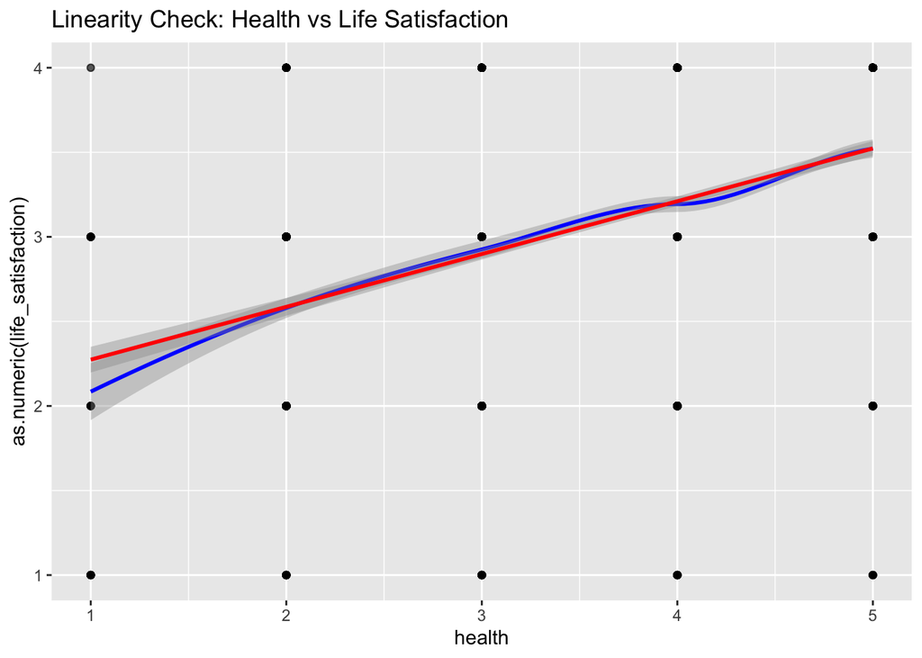

```r
ggplot(dfclean, aes(x = health, y = as.numeric(life_satisfaction))) +
  geom_point(alpha = 0.3) +
  geom_smooth(method = "loess", se = TRUE, color = "blue") +
  geom_smooth(method = "lm", color = "red") +
  labs(title = "Linearity Check: Health vs Life Satisfaction")
```

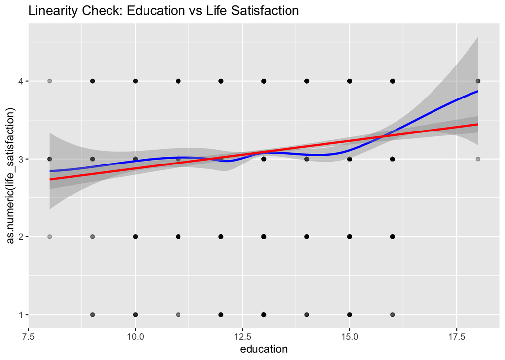

```r
ggplot(dfclean, aes(x = education, y = as.numeric(life_satisfaction))) +
  geom_point(alpha = 0.3) +
  geom_smooth(method = "loess", se = TRUE, color = "blue") +
  geom_smooth(method = "lm", color = "red") +
  labs(title = "Linearity Check: Education vs Life Satisfaction")
```

**Normality of Residuals:**

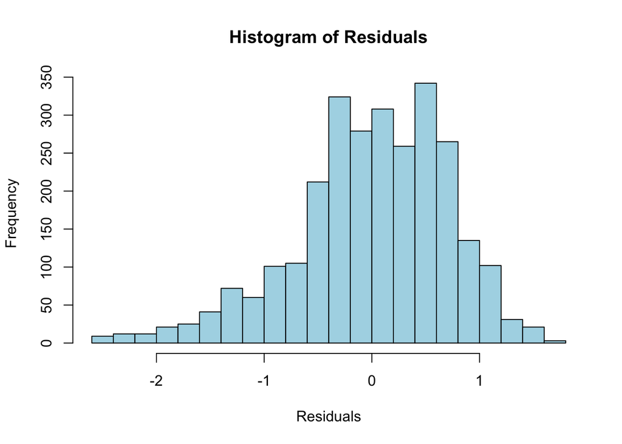

```r
hist(residuals(model_linear), main = "Histogram of Residuals",
     xlab = "Residuals", col = "lightblue", breaks = 20)
```

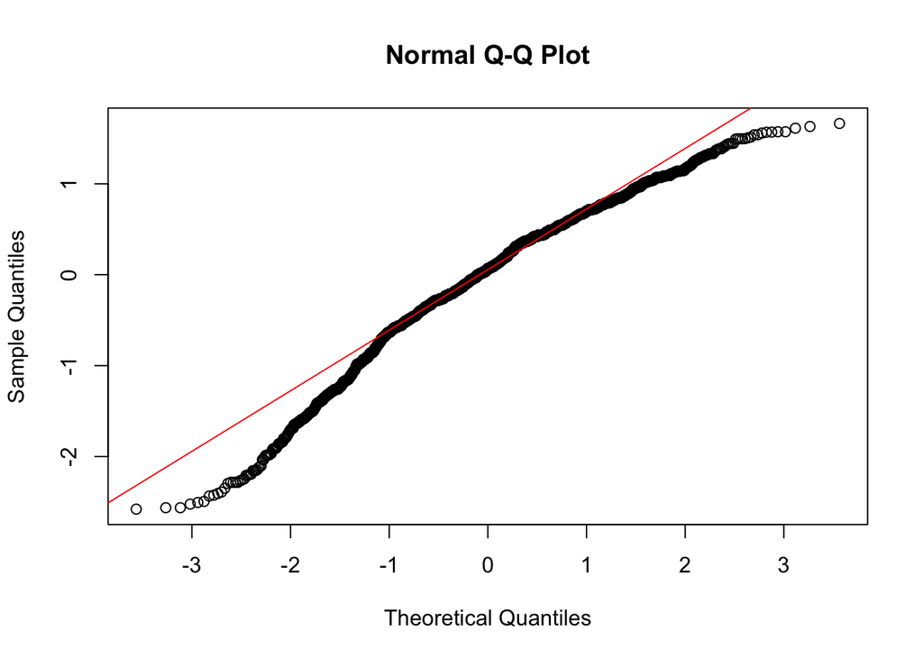

```r
qqnorm(residuals(model_linear))
qqline(residuals(model_linear), col = "red")
```

**Outlier Removal** — observations with absolute residuals > 2 removed:

```r
residuals_abs <- abs(residuals(model_linear))
outliers <- which(residuals_abs > 2)
df_cleaned <- dfclean[-outliers, ]
cat("Original n:", nrow(dfclean), "\nCleaned n:", nrow(df_cleaned))
```

```
## Original n: 2739
## Cleaned n: 2706
```

## Model 2: Corrected Model

Health and education are mean-centered; parental involvement variables are log-transformed (log(x+1)) to reduce skew.

```r
df_cleaned$health_centered     <- scale(df_cleaned$health,     center = TRUE, scale = FALSE)
df_cleaned$education_centered  <- scale(df_cleaned$education,  center = TRUE, scale = FALSE)
df_cleaned$mother_involvement_log <- log(df_cleaned$mother_involvement + 1)
df_cleaned$father_involvement_log <- log(df_cleaned$father_involvement + 1)
```

Sequential model building, adding one variable group at a time:

```r
model1 <- lm(as.numeric(life_satisfaction) ~ health_centered, data = df_cleaned)
model2 <- lm(as.numeric(life_satisfaction) ~ health_centered + work_last_week, data = df_cleaned)
model3 <- lm(as.numeric(life_satisfaction) ~ health_centered + work_last_week + gender, data = df_cleaned)
model4 <- lm(as.numeric(life_satisfaction) ~ health_centered + work_last_week + gender + race_color, data = df_cleaned)
model5 <- lm(as.numeric(life_satisfaction) ~ health_centered + work_last_week + gender + race_color + education_centered, data = df_cleaned)
model_corrected <- lm(as.numeric(life_satisfaction) ~ health_centered + work_last_week + gender +
                        race_color + education_centered +
                        mother_involvement_log + father_involvement_log, data = df_cleaned)
```

```r
stargazer::stargazer(model1, model2, model3, model4, model5, model_corrected,
                     type = "html",
                     title = "Sequential Model Building: Corrected Base Models",
                     column.labels = c("Health only", "+ Work", "+ Gender", "+ Race", "+ Education", "+ Parents"))
```

**Sequential Model Building: Corrected Base Models**

*Dependent variable:*

as.numeric(life_satisfaction)

Health only

(1)

(2)

(3)

(4)

(5)

(6)

health_centered

0.329***

0.328***

0.329***

0.329***

0.323***

0.315***

(0.013)

(0.013)

(0.013)

(0.013)

(0.013)

(0.013)

work_last_week

0.081***

0.081***

0.079***

0.071***

0.068**

(0.027)

(0.027)

(0.027)

(0.027)

(0.027)

gender

0.024

0.026

0.010

0.019

(0.026)

(0.026)

(0.027)

(0.026)

race_color

-0.085***

-0.071**

-0.061**

(0.028)

(0.029)

(0.028)

education_centered

0.042***

0.035***

(0.010)

(0.010)

mother_involvement_log

0.433***

(0.105)

father_involvement_log

0.205***

(0.049)

Constant

3.140***

3.089***

3.053***

3.110***

3.129***

2.153***

(0.013)

(0.022)

(0.046)

(0.050)

(0.050)

(0.180)

Observations

2,706

2,706

2,706

2,706

2,706

2,706

R<sup>2</sup>

0.198

0.201

0.201

0.204

0.209

0.220

Adjusted R<sup>2</sup>

0.198

0.200

0.200

0.203

0.208

0.218

Residual Std. Error

0.684 (df = 2704)

0.683 (df = 2703)

0.683 (df = 2702)

0.682 (df = 2701)

0.680 (df = 2700)

0.675 (df = 2698)

F Statistic

669.650*** (df = 1; 2704)

340.177*** (df = 2; 2703)

227.040*** (df = 3; 2702)

172.992*** (df = 4; 2701)

142.843*** (df = 5; 2700)

108.880*** (df = 7; 2698)

*Note:*

p<0.1; p<0.05; p<0.01

**AIC comparison across all models:**

```r
data.frame(
  Model = c("Base (uncorrected)", "M1", "M2", "M3", "M4", "M5", "Corrected"),
  AIC = c(AIC(model_linear), AIC(model1), AIC(model2), AIC(model3),
          AIC(model4), AIC(model5), AIC(model_corrected))
)
```

```
##                Model      AIC
## 1 Base (uncorrected) 5964.122
## 2                 M1 5628.268
## 3                 M2 5621.495
## 4                 M3 5622.681
## 5                 M4 5615.815
## 6                 M5 5599.919
## 7          Corrected 5565.743
```

## Model 3: Interaction of Health and Employment Status

Tests whether the effect of health on life satisfaction is moderated by employment status.

```r
model_interaction <- lm(as.numeric(life_satisfaction) ~ health_centered + work_last_week +
                          gender + race_color + education_centered +
                          mother_involvement_log + father_involvement_log +
                          health_centered:work_last_week,
                        data = df_cleaned)

cat("Interaction model AIC:", AIC(model_interaction))
```

```
## Interaction model AIC: 5566.536
```

```r
stargazer::stargazer(model_corrected, model_interaction,
                     type = "html",
                     title = "Corrected Base Model vs. Interaction Model",
                     column.labels = c("Corrected Base", "With Interaction"))
```

**Corrected Base Model vs. Interaction Model**

|  | *Dependent variable:* |  |
| --- | --- | --- |
|  | as.numeric(life_satisfaction) |  |
|  | Corrected Base | With Interaction |
|  | (1) | (2) |
| health_centered | 0.315*** | 0.332*** |
|  | (0.013) | (0.020) |
| work_last_week | 0.068** | 0.068** |
|  | (0.027) | (0.027) |
| gender | 0.019 | 0.018 |
|  | (0.026) | (0.026) |
| race_color | -0.061** | -0.061** |
|  | (0.028) | (0.028) |
| education_centered | 0.035*** | 0.036*** |
|  | (0.010) | (0.010) |
| mother_involvement_log | 0.433*** | 0.436*** |
|  | (0.105) | (0.105) |
| father_involvement_log | 0.205*** | 0.204*** |
|  | (0.049) | (0.049) |
| health_centered:work_last_week |  | -0.028 |
|  |  | (0.026) |
| Constant | 2.153*** | 2.152*** |
|  | (0.180) | (0.180) |
| Observations | 2,706 | 2,706 |
| R<sup>2</sup> | 0.220 | 0.221 |
| Adjusted R<sup>2</sup> | 0.218 | 0.218 |
| Residual Std. Error | 0.675 (df = 2698) | 0.675 (df = 2697) |
| F Statistic | 108.880*** (df = 7; 2698) | 95.428*** (df = 8; 2697) |
| *Note:* | p<0.1; p<0.05; p<0.01 |  |